```python
import numpy as np
import matplotlib.pyplot as plt
import csv
from sklearn.tree import DecisionTreeRegressor
from sklearn.tree import DecisionTreeClassifier
from sklearn.ensemble import RandomForestClassifier
from sklearn.ensemble import GradientBoostingClassifier
from matplotlib.colors import ListedColormap
```

# 4

Load data

```python
# load training set
ytrain = []
Xtrain = []
with open('HW3train.csv', 'r') as csvfile:
    reader = csv.reader(csvfile, delimiter=',',lineterminator='\n')
    for row in reader:
        if len(row)==3:
            ytrain.append( int(row[0]) )
            Xtrain.append( [float(row[1]) , float(row[2]) ])


Xtrain = np.array(Xtrain)
ytrain = np.array(ytrain)
```

```python
# load testing set
ytest = []
Xtest = []
with open('HW3test.csv', 'r') as csvfile:
    reader = csv.reader(csvfile, delimiter=',',lineterminator='\n')
    for row in reader:
        if len(row)==3:
            ytest.append( int(row[0]) )
            Xtest.append( [float(row[1]) , float(row[2]) ])

Xtest = np.array(Xtest)
ytest = np.array(ytest)
```

To visualize the region for each class $$y\in\{+1,+2,+3\},$$ we will use a meshgrid

```python
h = .02  # step size in the mesh (increase if code runs too slow)

# Plot the decision boundary. For that, we will assign a color to each
# point in the mesh [x_min, x_max]x[y_min, y_max].
x1_min, x1_max = Xtrain[:, 0].min() - 1, Xtrain[:, 0].max() + 1
x2_min, x2_max = Xtrain[:, 1].min() - 1, Xtrain[:, 1].max() + 1
x1mesh, x2mesh = np.meshgrid(np.arange(x1_min, x1_max, h),
                         np.arange(x2_min, x2_max, h))
```

```python
# Create color maps
cmap_light = ListedColormap(['lightblue', 'lightcoral', 'grey'])
cmap_bold = ListedColormap(['blue', 'red', 'black'])
```

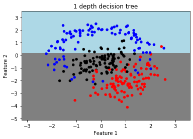

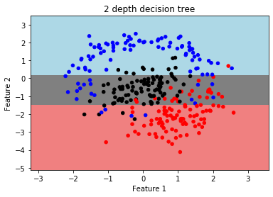

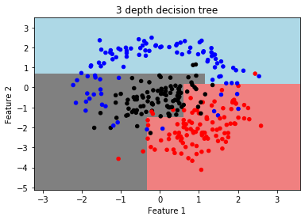

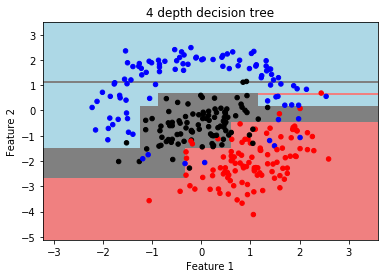

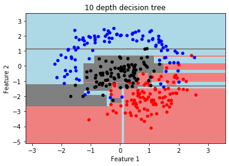

```python
for depth in [1,2,3,4,10]:
    # we create an instance of Decision Tree Classifier and fit the data.

    clf = DecisionTreeClassifier(criterion='gini',splitter='best',max_depth=depth)
    clf.fit(Xtrain, ytrain)

    Z = clf.predict(np.c_[x1mesh.ravel(), x2mesh.ravel()])

    # Put the result into a color plot
    Z = Z.reshape(x1mesh.shape)

    # Plot the training points with the mesh
    plt.figure()
    plt.pcolormesh(x1mesh, x2mesh, Z, cmap=cmap_light)
    ytrain_colors = [y-1 for y in ytrain]
    plt.scatter(Xtrain[:, 0], Xtrain[:, 1], c=ytrain_colors, cmap=cmap_bold, s=20)
    plt.xlim(x1_min, x1_max)
    plt.ylim(x2_min, x2_max)
    plt.title('%i depth decision tree' % (depth))
    plt.xlabel('Feature 1')
    plt.ylabel('Feature 2')

plt.show()
```

# 4 B Accuracy plots

```
Working on depth=1
1
Working on depth=2
2
Working on depth=3
3
Working on depth=4
4
Working on depth=5
5
Working on depth=6
6
Working on depth=7
7
Working on depth=8
8
Working on depth=9
9
Working on depth=10
9
The best max_depth=4 with test acc = 0.8800
The plots are included above
```

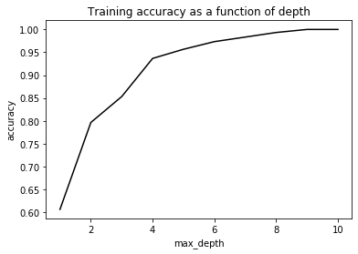

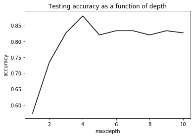

```python
# Now make plots of Training Accuracy and plots of Testing Accuracy for KNN for k in {1,3,5,7,9,11,13,15}

trainacc = []
testacc = []
depthrange = range(1,11,1)
for depth in depthrange:
    print('Working on depth=%i'%(depth))
    clf = DecisionTreeClassifier(criterion='gini',splitter='best',max_depth=depth)
    clf.fit(Xtrain, ytrain)
    actualdepth = int(clf.get_depth())
#     print(depth)
    print(actualdepth)
#     print('maxdepth = %i depth=%i'(depth, actualdepth))
    trainacc.append( clf.score(Xtrain,ytrain) )
    testacc.append( clf.score(Xtest,ytest) )
#     print('\tThe training accuracy is %.4f'%(clf.score(Xtrain,ytrain)))
#     print('\tThe testing accuracy is %.4f'%(clf.score(Xtest,ytest)))


plt.figure()

plt.plot(depthrange,trainacc,color='black')
plt.title('Training accuracy as a function of depth')
plt.xlabel('max_depth')
plt.ylabel('accuracy')

plt.figure()

plt.plot(depthrange,testacc,color='black')
plt.title('Testing accuracy as a function of depth')
plt.xlabel('maxdepth')
plt.ylabel('accuracy')

idx = testacc.index(max(testacc))
print('The best max_depth=%i with test acc = %.4f'%(depthrange[idx],max(testacc)))
print('The plots are included above')
```

# 4 C and D: Bagging

```
The best num_trees=200 for max_depth=1 with test acc = 0.7400
The best num_trees=100 for max_depth=2 with test acc = 0.7600
The best num_trees=50 for max_depth=3 with test acc = 0.8467
The best num_trees=50 for max_depth=4 with test acc = 0.8933
The best num_trees=25 for max_depth=5 with test acc = 0.8667
The best num_trees=10 for max_depth=6 with test acc = 0.8733
The best num_trees=5 for max_depth=7 with test acc = 0.8600
The best num_trees=100 for max_depth=8 with test acc = 0.8533
The best num_trees=5 for max_depth=9 with test acc = 0.8667
The best num_trees=10 for max_depth=10 with test acc = 0.8667
```

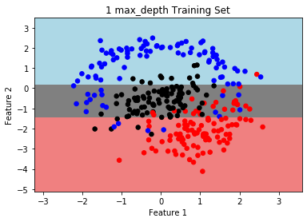

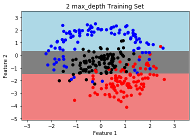

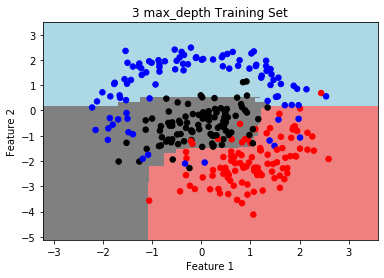

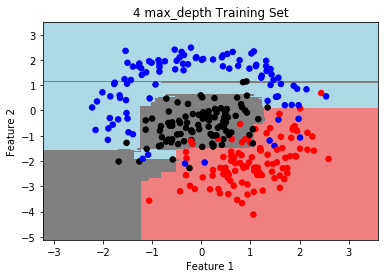

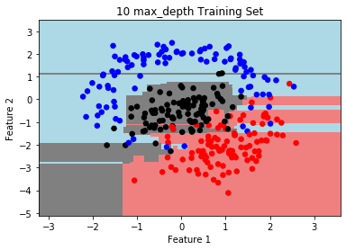

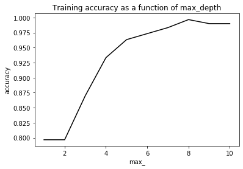

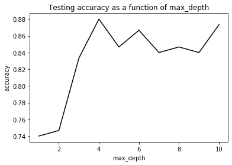

```python
numtreerange = [1,5,10,25,50,100,200]
overalltestacc = []
overalltrainacc=[]
depthrange = range(1,11)
for depth in depthrange:

    best_num_trees = 0
    best_acc = 0

    for num_trees in numtreerange:
        clf = RandomForestClassifier(bootstrap=True,n_estimators=num_trees,max_features=None,criterion='gini',max_depth=depth)
        clf.fit(Xtrain, ytrain)

        testacc= clf.score(Xtest,ytest)
        if testacc >= best_acc:
            best_acc = testacc
            best_num_trees = num_trees
    print('The best num_trees=%i for max_depth=%i with test acc = %.4f'%(best_num_trees,depth,best_acc))

    clf = RandomForestClassifier(bootstrap=True,n_estimators=best_num_trees,max_features=None,criterion='gini',max_depth=depth)
    clf.fit(Xtrain, ytrain)
    overalltrainacc.append( clf.score(Xtrain,ytrain) )
    overalltestacc.append( clf.score(Xtest,ytest) )

    if depth in [1,2,3,4,10]:

        Z = clf.predict(np.c_[x1mesh.ravel(), x2mesh.ravel()])

        # Put the result into a color plot
        Z = Z.reshape(x1mesh.shape)


        # Plot the testing points with the mesh
        ypred = clf.predict(Xtest)
        plt.figure()
        plt.pcolormesh(x1mesh, x2mesh, Z, cmap=cmap_light)
        ytest_colors = [y-1 for y in ytest]
        plt.scatter(Xtrain[:, 0], Xtrain[:, 1], c=ytrain_colors, cmap=cmap_bold, s=30)
        plt.xlim(x1_min, x1_max)
        plt.ylim(x2_min, x2_max)
        plt.title('%i max_depth Training Set' % (depth))
        plt.xlabel('Feature 1')
        plt.ylabel('Feature 2')

plt.figure()

plt.plot(depthrange,overalltrainacc,color='black')
plt.title('Training accuracy as a function of max_depth')
plt.xlabel('max_')
plt.ylabel('accuracy')

plt.figure()

plt.plot(depthrange,overalltestacc,color='black')
plt.title('Testing accuracy as a function of max_depth')
plt.xlabel('max_depth')
plt.ylabel('accuracy')

plt.show()

# idx = overalltestacc.index(max(overalltestacc))
# print('The best $k$=%i with test acc = %.4f'%(idx+1,max(overalltestacc)))
```

So for this case, Bagging does not seem to improve performance much (does a tiny bit) over a single decision tree

# 4. E and F: Boosting

```
Working on max_depth = 1
The best rate=1.000e+00 and num_trees=5 for max_depth with test acc = 0.8933



Working on max_depth = 2
The best rate=5.179e-02 and num_trees=50 for max_depth with test acc = 0.9000



Working on max_depth = 3
The best rate=8.483e-02 and num_trees=1 for max_depth with test acc = 0.8800



Working on max_depth = 4
The best rate=1.389e-01 and num_trees=25 for max_depth with test acc = 0.8867



Working on max_depth = 5
The best rate=1.000e+00 and num_trees=25 for max_depth with test acc = 0.8733



Working on max_depth = 6
The best rate=1.000e+00 and num_trees=10 for max_depth with test acc = 0.8733



Working on max_depth = 7
The best rate=6.105e-01 and num_trees=10 for max_depth with test acc = 0.8733



Working on max_depth = 8
The best rate=3.728e-01 and num_trees=25 for max_depth with test acc = 0.8600



Working on max_depth = 9
The best rate=3.728e-01 and num_trees=25 for max_depth with test acc = 0.8600



Working on max_depth = 10
The best rate=2.276e-01 and num_trees=25 for max_depth with test acc = 0.8533
```

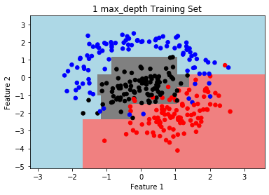

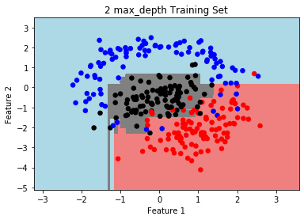

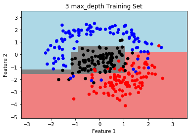

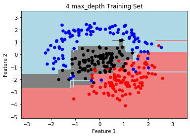

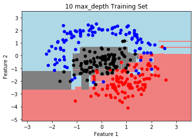

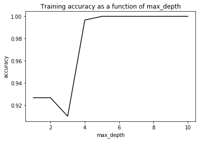

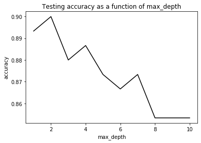

```python
learnrange = np.logspace(-3,0,15,base=10)

depthrange = range(1,11)

numtreerange = [1,5,10,25,50,100,200]

overalltestacc = []
overalltrainacc = []

for depth in range(1,11):
    print('\n\n\nWorking on max_depth = %i'%(depth))

    best_num_trees = 0
    best_rate = 0
    best_acc = 0

    for num_trees in numtreerange:
        for rate in learnrange:
            # we create an instance of  Classifier and fit the data.
            clf = GradientBoostingClassifier(learning_rate=rate, n_estimators=num_trees,max_depth=depth )
            clf.fit(Xtrain, ytrain)

            testacc= clf.score(Xtest,ytest)
            if testacc>best_acc:
                best_acc = testacc
                best_rate = rate
                best_num_trees = num_trees

    print('The best rate=%.3e and num_trees=%i for max_depth with test acc = %.4f'%(best_rate,best_num_trees,best_acc))

    #retrain with this best rate
    clf = GradientBoostingClassifier(learning_rate=best_rate, n_estimators=best_num_trees,max_depth=depth )
    clf.fit(Xtrain, ytrain)

    overalltrainacc.append( clf.score(Xtrain,ytrain) )
    overalltestacc.append( clf.score(Xtest,ytest) )

    if depth in [1,2,3,4,10]:
        Z = clf.predict(np.c_[x1mesh.ravel(), x2mesh.ravel()])

        # Put the result into a color plot
        Z = Z.reshape(x1mesh.shape)


        # Plot the testing points with the mesh
        ypred = clf.predict(Xtest)
        plt.figure()
        plt.pcolormesh(x1mesh, x2mesh, Z, cmap=cmap_light)
        ytest_colors = [y-1 for y in ytest]
        plt.scatter(Xtrain[:, 0], Xtrain[:, 1], c=ytrain_colors, cmap=cmap_bold, s=30)
        plt.xlim(x1_min, x1_max)
        plt.ylim(x2_min, x2_max)
        plt.title('%i max_depth Training Set' % (depth))
        plt.xlabel('Feature 1')
        plt.ylabel('Feature 2')



plt.figure()

plt.plot(range(1,11),overalltrainacc,color='black')
plt.title('Training accuracy as a function of max_depth')
plt.xlabel('max_depth')
plt.ylabel('accuracy')

plt.figure()

plt.plot(range(1,11),overalltestacc,color='black')
plt.title('Testing accuracy as a function of max_depth')
plt.xlabel('max_depth')
plt.ylabel('accuracy')

plt.show()
```

In terms of performance, all the decision tree methods perform fairly well, with bagging better than single decision tree and boosting better than bagging. But none of these methods performed as well kNN or SVMs from HW 3 (testing accuracies of 0.913 and 0.92 respectively).

The decision region shapes for decision tree based methods (espectially single decision tree and bagging) were much more rectangular than methods from HW 3, which typically had smooth boundaries. This was expected, due to how each split of the feature space is along a single feature (so all boundaries from a single tree were vertical or horizontal).

Max depth does have a significant effect on performance for a single decision tree and bagging, where increasing from max_depth of 1 to max_depth of 4 allowed for large gains in accuracy. Interestingly, for boosting the max_depth even of 1 performed quite well. All methods had visible signs of overfitting, where training accuracy would flatline or increase mildly with a drop in test performance as max_depth increased (up until the actual depth flatlines).